# Lecture 6: Column transformer and text features

Firas Moosvi (Slides adapted from Varada Kolhatkar)

# Recap: Preprocessing mistakes

## Data

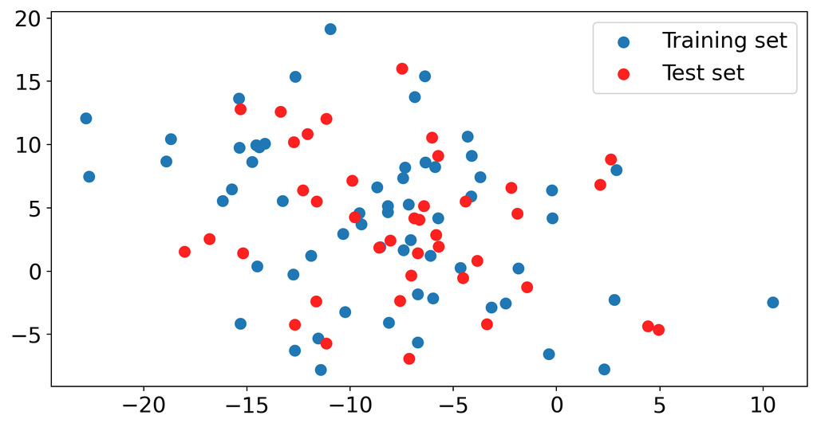

```python
X, y = make_blobs(n_samples=100, centers=3, random_state=12, cluster_std=5) # make synthetic data
X_train_toy, X_test_toy, y_train_toy, y_test_toy = train_test_split(
    X, y, random_state=5, test_size=0.4) # split it into training and test sets
# Visualize the training data
plt.scatter(X_train_toy[:, 0], X_train_toy[:, 1], label="Training set", s=60)
plt.scatter(
    X_test_toy[:, 0], X_test_toy[:, 1], color=mglearn.cm2(1), label="Test set", s=60
)
plt.legend(loc="upper right")
```

## ❌ Bad methodology 1

- What’s wrong with scaling data separately?

```python
scaler = StandardScaler() # Creating a scalert object
scaler.fit(X_train_toy) # Calling fit on the training data
train_scaled = scaler.transform(
    X_train_toy
)  # Transforming the training data using the scaler fit on training data

scaler = StandardScaler()  # Creating a separate object for scaling test data
scaler.fit(X_test_toy)  # Calling fit on the test data
test_scaled = scaler.transform(
    X_test_toy
)  # Transforming the test data using the scaler fit on test data

knn = KNeighborsClassifier()
knn.fit(train_scaled, y_train_toy)
print(f"Training score: {knn.score(train_scaled, y_train_toy):.2f}")
print(f"Test score: {knn.score(test_scaled, y_test_toy):.2f}") # misleading scores
```

```
Training score: 0.63
Test score: 0.60
```

## Scaling train and test data separately

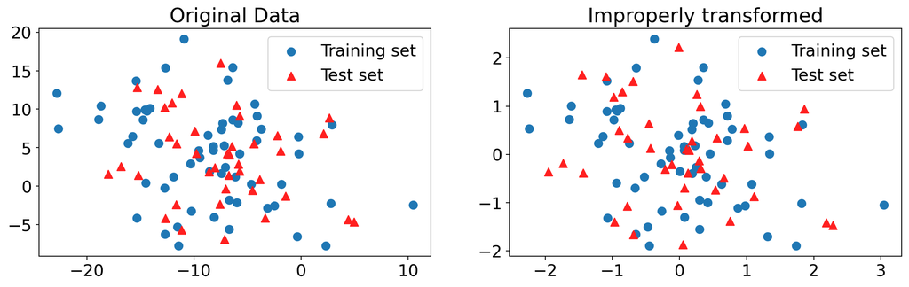

## ❌ Bad methodology 2

- What’s wrong with the approach below?

```python
# join the train and test sets back together
XX = np.vstack((X_train_toy, X_test_toy))

scaler = StandardScaler()
scaler.fit(XX)
XX_scaled = scaler.transform(XX)

XX_train = XX_scaled[:X_train_toy.shape[0]]
XX_test = XX_scaled[X_train_toy.shape[0]:]

knn = KNeighborsClassifier()
knn.fit(XX_train, y_train_toy)
print(f"Training score: {knn.score(XX_train, y_train_toy):.2f}")  # Misleading score
print(f"Test score: {knn.score(XX_test, y_test_toy):.2f}")  # Misleading score
```

```
Training score: 0.63
Test score: 0.55
```

## ❌ Bad methodology 3

- What’s wrong with the approach below?

```python
knn = KNeighborsClassifier()

scaler = StandardScaler()
scaler.fit(X_train_toy)
X_train_scaled = scaler.transform(X_train_toy)
X_test_scaled = scaler.transform(X_test_toy)
cross_val_score(knn, X_train_scaled, y_train_toy)
```

```
array([0.25      , 0.5       , 0.58333333, 0.58333333, 0.41666667])
```

## Improper preprocessing

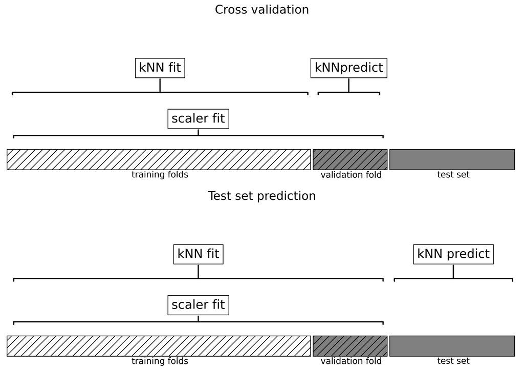

## Proper preprocessing

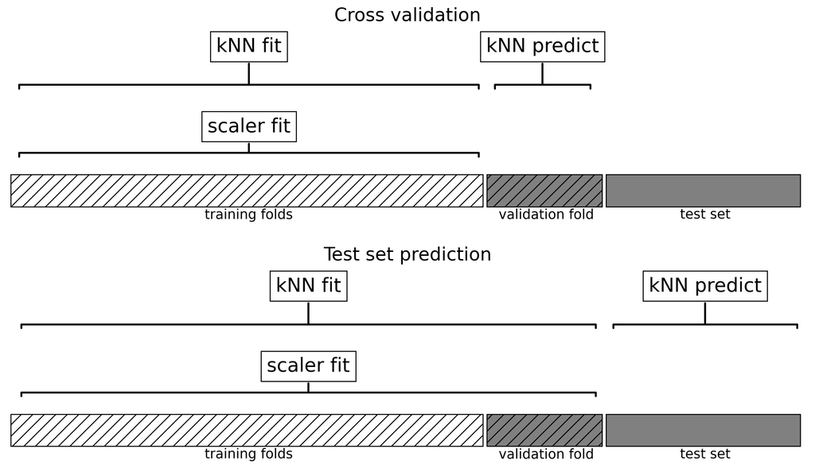

## Common scenarios of data leakage ⛔️

- **Fitting preprocessing on validation or test data:** The preprocessing “learns” from data it shouldn’t see, giving your model unfair information.
- **Fitting preprocessing on the full dataset (train + validation/test):** Even a small peek at validation/test data contaminates the training process.
- **Fitting preprocessing before cross-validation:** The preprocessing step has already “seen” all the data, so each validation fold is no longer truly unseen.

## Avoiding data leakage ✅

- Ensure the **training process remains completely independent of the validation/test data**.
- Fit preprocessing steps only on the training data (e.g., imputer learns medians from training set).
- Apply the same preprocessing steps to both training and validation/test data.
- Use the validation set only for hyperparameter tuning. It must not contribute to model training.
- Use **`sklearn` pipelines** to automatically handle preprocessing and modeling without breaking the golden rule.

## Recap: `sklearn` Pipelines

- Pipeline is a way to chain multiple steps (e.g., preprocessing + model fitting) into a single workflow.
- If you build a pipeline with preprocessing + model, then during cross-validation:
  - Each preprocessing step fits and transforms only on the training fold.
  - The same preprocessing steps are then applied (transform only) to the validation fold.
  - Finally, the model is trained on the preprocessed training data and evaluated on the preprocessed validation data.

## Recap: `sklearn` Pipelines

- Simplify the code and improves readability.
- Reduce the risk of data leakage by ensuring proper transformation of the training and test sets.
- Automatically apply transformations in sequence.
- **Example:**
  - Chaining a `StandardScaler` with a `KNeighborsClassifier` model.

```python
from sklearn.pipeline import make_pipeline

pipe_knn = make_pipeline(StandardScaler(), KNeighborsClassifier())

# Correct way to do cross validation without breaking the golden rule.
cross_val_score(pipe_knn, X_train_toy, y_train_toy)
```

```
array([0.25      , 0.5       , 0.5       , 0.58333333, 0.41666667])
```

## `sklearn`’s `ColumnTransformer`

- Use ColumnTransformer to build all our transformations together into one object

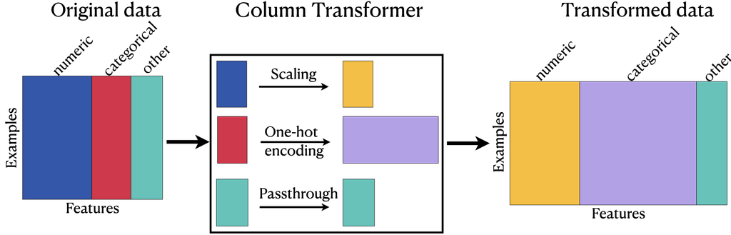

- Use a column transformer with sklearn pipelines.

## (Clicker) Exercise 6.1

**Select all of the following statements which are TRUE.**

- 1. You could carry out cross-validation by passing a `ColumnTransformer` object to `cross_validate`.
- 2. After applying column transformer, the order of the columns in the transformed data has to be the same as the order of the columns in the original data.
- 3. After applying a column transformer, the transformed data is always going to be of different shape than the original data.
- 4. When you call `fit_transform` on a `ColumnTransformer` object, you get a numpy ndarray.

# More preprocessing

## Remarks on preprocessing

- There is no one-size-fits-all solution in data preprocessing, and decisions often involve a degree of subjectivity.
  - Exploratory data analysis and domain knowledge inform these decisions
- Always consider the specific goals of your project when deciding how to encode features.

## Alternative methods for scaling

- [StandardScaler](https://scikit-learn.org/stable/modules/generated/sklearn.preprocessing.StandardScaler.html)
  - Good choice when the column follows a normal distribution or a distribution somewhat like a normal distribution.
- [MinMaxScaler](https://scikit-learn.org/stable/modules/generated/sklearn.preprocessing.MinMaxScaler.html): Transform each feature to a desired range. Appropriate when
  - Good choice for features such as human age, where there is a fixed range of values and the feature is uniformly distributed across the range
- [Normalizer](https://scikit-learn.org/stable/modules/generated/sklearn.preprocessing.Normalizer.html): Works on rows rather than columns. Normalize examples individually to unit norm.
  - Good choice for frequency-type data
- [Log scaling](https://scikit-learn.org/stable/modules/preprocessing.html#custom-transformers)
  - Good choice for features following power law distribution (e.g., counts of followers, salary or income )
- …

## Ordinal encoding vs. One-hot encoding

- Ordinal Encoding: Encodes categorical features as an integer array.
- One-hot Encoding: Creates binary columns for each category’s presence.
- Sometimes how we encode a specific feature depends upon the context.

## Ordinal encoding vs. One-hot encoding

- Consider **weather** feature and its four categories: Sunny (☀️), Cloudy (🌥️), Rainy (⛈️), Snowy (❄️)
- Which encoding would you use in each of the following scenarios?
  - **Predicting traffic volume**
  - **Predicting severity of weather-related road incidents**

## Ordinal encoding vs. One-hot encoding

- Consider **weather** feature and its four categories: Sunny (☀️), Cloudy (🌥️), Rainy (⛈️), Snowy (❄️)
- **Predicting traffic volume:** Using one-hot encoding would make sense here because the impact of different weather conditions on traffic volume does not necessarily follow a clear order and different weather conditions could have very distinct effects.
- **Predicting severity of weather-related road incidents:** An ordinal encoding might be more appropriate if you define your weather categories from least to most severe as this could correlate directly with the likelihood or severity of incidents.

## How to deal with unseen categories?

- In `sklearn` we can use `handle_unknown='ignore'` with `OneHotEncoder` to safely ignore unseen categories during transform.
- In each of the following scenarios, identify whether it’s a reasonable strategy or not.
  - Example 1: Suppose you are building a model to predict customer behavior (e.g., purchase likelihood) based on features like `location`, `device_type`, and `product_category`. During training, you have observed a set of categories for `product_category`, but in the future, new product categories might be added.
  - Example 2: You’re building a model to predict disease diagnosis based on symptoms, where each symptom is categorized (e.g., fever, headache, nausea).

## `handle_unknown = "ignore"` of `OneHotEncoder`

- Reasonable use: When unseen categories are less likely to impact the model’s prediction accuracy (e.g., product categories in e-commerce), and you prefer to avoid breaking the model.
- Not-so-reasonable use: When unseen categories could provide critical new information that could significantly alter predictions (e.g., in medical diagnostics), ignoring them could result in a poor or dangerous outcome.

## `drop="if_binary"` argument of OneHotEncoder

- drop=‘if_binary’ argument in OneHotEncoder:
- Reduces redundancy by dropping one of the columns if the feature is binary.

## Categorical variables with too many categories

- Strategies for categorical variables with too many categories:
  - Dimensionality reduction techniques
  - Bucketing categories into ‘others’
  - Clustering or grouping categories manually
  - Only considering top-N categories
  - …

## Dealing with text features

- Preprocessing text to fit into machine learning models using text vectorization.
- Bag of words representation

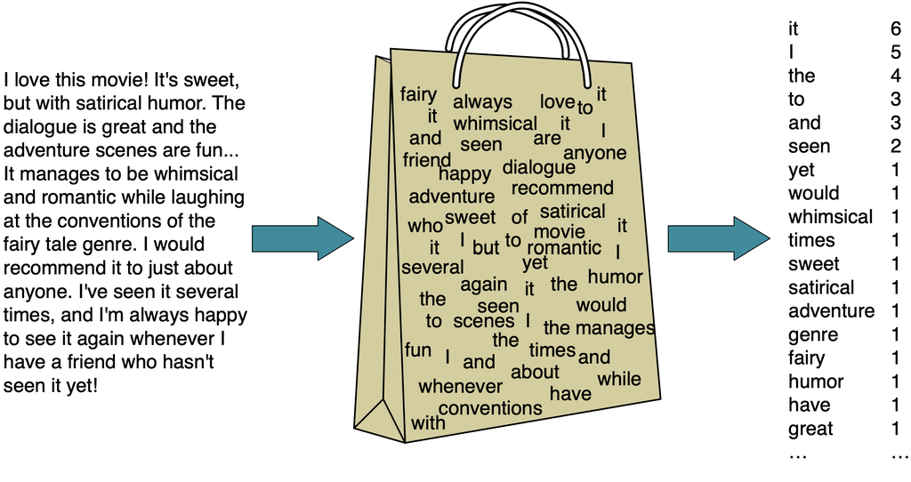

## `sklearn` `CountVectorizer`

- Use `scikit-learn`’s `CountVectorizer` to encode text data
- `CountVectorizer`: Transforms text into a matrix of token counts
- Important parameters:
  - `max_features`: Control the number of features used in the model
  - `max_df`, `min_df`: Control document frequency thresholds
  - `ngram_range`: Defines the range of n-grams to be extracted
  - `stop_words`: Enables the removal of common words that are typically uninformative in most applications, such as “and”, “the”, etc.

## Incorporating text features in a machine learning pipeline

```python
from sklearn.feature_extraction.text import CountVectorizer
from sklearn.svm import SVC
from sklearn.pipeline import make_pipeline

text_pipeline = make_pipeline(
    CountVectorizer(),
    SVC()
)
```

## (Clicker) Exercise 6.2

Select all of the following statements which are TRUE.

- 1. `handle_unknown="ignore"` would treat all unknown categories equally.
- 2. As you increase the value for `max_features` hyperparameter of `CountVectorizer` the training score is likely to go up.
- 3. Suppose you are encoding text data using `CountVectorizer`. If you encounter a word in the validation or the test split that’s not available in the training data, we’ll get an error.
- 4. In the code below, inside `cross_validate`, each fold might have slightly different number of features (columns) in the fold.

```python
pipe = make_pipeline(CountVectorizer(), SVC())
cross_validate(pipe, X_train, y_train)
```